# PML final project

Angel Dzhekov

## Background

“Using devices such as Jawbone Up, Nike FuelBand, and Fitbit it is now possible to collect a large amount of data about personal activity relatively inexpensively. These type of devices are part of the quantified self movement – a group of enthusiasts who take measurements about themselves regularly to improve their health, to find patterns in their behavior, or because they are tech geeks. One thing that people regularly do is quantify how much of a particular activity they do, but they rarely quantify how well they do it. In this project, your goal will be to use data from accelerometers on the belt, forearm, arm, and dumbell of 6 participants. They were asked to perform barbell lifts correctly and incorrectly in 5 different ways. More information is available from the website here: http://groupware.les.inf.puc-rio.br/har (see the section on the Weight Lifting Exercise Dataset).”

## loading training and testing data

```r
URLtraining <- "http://d396qusza40orc.cloudfront.net/predmachlearn/pml-training.csv"
URLtesting  <- "http://d396qusza40orc.cloudfront.net/predmachlearn/pml-testing.csv"
pmlTraining <- read.csv(url(URLtraining), stringsAsFactors = FALSE)
pmlTesting  <- read.csv(url(URLtesting), stringsAsFactors = FALSE)
```

## loading the required packages

```r
library(caret)
library(dplyr)
library(corrplot)
library(randomForest)
library(MASS)
```

### Data cleaning, division and preparation

Removing of first seven columns: “X”, user_name, “raw_timestamp_part_1”, “raw_timestamp_part_2”, “cvtd_timestamp”, “new_window”, “num_window”, which appear to have no use for the machine learning algorithms.

```r
pmlTesting <- pmlTesting[, -c(1:7)]
pmlTraining <- pmlTraining[, -c(1:7)]
```

```r
pmlTraining <- pmlTraining[,colSums(is.na(pmlTraining)) == 0]
pmlTesting <- pmlTesting[,colSums(is.na(pmlTesting)) == 0]
```

removing NA values from the training set

```r
pmlTraining[is.na(pmlTraining)] <- ""
```

data partitioning

```r
inTrain <- createDataPartition(y=pmlTraining$classe, p=0.7, list = FALSE)
training <- pmlTraining[inTrain, ]
testing <- pmlTraining[-inTrain, ]
```

Removing of Near Zero Variance variables

```r
nsv <- nearZeroVar(training, saveMetrics = TRUE)

remover <- c(1:nrow(nsv))
remover <- remover[nsv$nzv]

training <- training[, -remover]
testing <- testing[, -remover]
```

Removing “classe” variable for the needs of the creation of correlation matrix

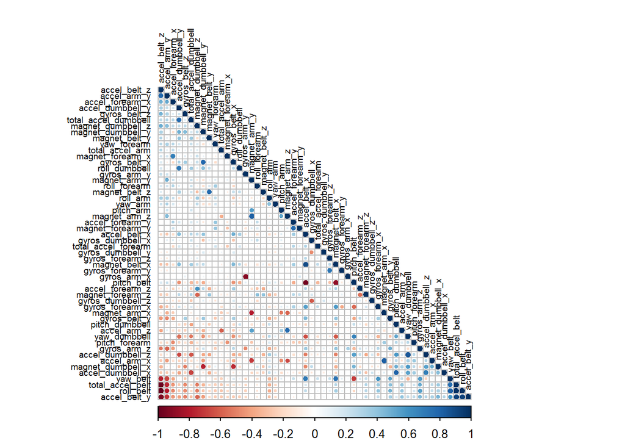

```r
trainAux <- training[, -53]
CorMat <- cor(trainAux)
corrplot(CorMat, order = "FPC", method = "circle", type = "lower", tl.cex = 0.6, tl.col = rgb(0, 0, 0))
```

Removing highly correlated variables

```r
CorMat[upper.tri(CorMat)] <- 0
diag(CorMat) <- 0
trainAuxNew <- trainAux[,!apply(CorMat,2,function(x) any(abs(x) > 0.95))]
```

returning the “classe” variable to the training set

```r
classe <- training$classe
training  <- cbind(trainAuxNew, classe)
```

## Model building

I will try Random Forest and Linear Discirminant Analysis methods and use the more accurate one for the final prediction of the test set.

```r
set.seed(1801)
controlRF <- trainControl(method="cv", number=3, verboseIter=FALSE)
modelFitRF <- train(classe ~ ., data=training, method="rf",
                          trControl=controlRF)
modelFitRF$finalModel
```

```
##
## Call:
##  randomForest(x = x, y = y, mtry = param$mtry)
##                Type of random forest: classification
##                      Number of trees: 500
## No. of variables tried at each split: 25
##
##         OOB estimate of  error rate: 0.76%
## Confusion matrix:
##      A    B    C    D    E class.error
## A 3901    4    1    0    0 0.001280082
## B   19 2633    5    1    0 0.009405568
## C    0   23 2362   11    0 0.014190317
## D    2    0   26 2223    1 0.012877442
## E    0    0    6    5 2514 0.004356436
```

Prediction on the test part of the training set

```r
predictRandForest <- predict(modelFitRF, newdata=testing)
confMatRandForest <- confusionMatrix(predictRandForest, testing$classe)
confMatRandForest
```

```
## Confusion Matrix and Statistics
##
##           Reference
## Prediction    A    B    C    D    E
##          A 1672   14    0    0    0
##          B    1 1123    8    0    0
##          C    0    1 1015   11    1
##          D    0    0    3  951    7
##          E    1    1    0    2 1074
##
## Overall Statistics
##
##                Accuracy : 0.9915
##                  95% CI : (0.9888, 0.9937)
##     No Information Rate : 0.2845
##     P-Value [Acc > NIR] : < 2.2e-16
##
##                   Kappa : 0.9893
##  Mcnemar's Test P-Value : NA
##
## Statistics by Class:
##
##                      Class: A Class: B Class: C Class: D Class: E
## Sensitivity            0.9988   0.9860   0.9893   0.9865   0.9926
## Specificity            0.9967   0.9981   0.9973   0.9980   0.9992
## Pos Pred Value         0.9917   0.9920   0.9874   0.9896   0.9963
## Neg Pred Value         0.9995   0.9966   0.9977   0.9974   0.9983
## Prevalence             0.2845   0.1935   0.1743   0.1638   0.1839
## Detection Rate         0.2841   0.1908   0.1725   0.1616   0.1825
## Detection Prevalence   0.2865   0.1924   0.1747   0.1633   0.1832
## Balanced Accuracy      0.9977   0.9920   0.9933   0.9922   0.9959
```

```r
modlda <- train(classe ~ ., data = training, method = "lda")
modlda$finalModel
```

[output not shown]

[output cut: 125 more lines]

[output not shown]

```r
confusionMatrix(testing$classe, predict(modlda, testing))
```

```
## Confusion Matrix and Statistics
##
##           Reference
## Prediction    A    B    C    D    E
##          A 1310   38  165  154    7
##          B  184  711  125   55   64
##          C   80   97  685  141   23
##          D   47   71  128  656   62
##          E   44  200   87  121  630
##
## Overall Statistics
##
##                Accuracy : 0.6783
##                  95% CI : (0.6662, 0.6903)
##     No Information Rate : 0.2829
##     P-Value [Acc > NIR] : < 2.2e-16
##
##                   Kappa : 0.5937
##  Mcnemar's Test P-Value : < 2.2e-16
##
## Statistics by Class:
##
##                      Class: A Class: B Class: C Class: D Class: E
## Sensitivity            0.7868   0.6365   0.5756   0.5821   0.8015
## Specificity            0.9137   0.9102   0.9274   0.9353   0.9114
## Pos Pred Value         0.7826   0.6242   0.6676   0.6805   0.5823
## Neg Pred Value         0.9157   0.9145   0.8961   0.9043   0.9675
## Prevalence             0.2829   0.1898   0.2022   0.1915   0.1336
## Detection Rate         0.2226   0.1208   0.1164   0.1115   0.1071
## Detection Prevalence   0.2845   0.1935   0.1743   0.1638   0.1839
## Balanced Accuracy      0.8503   0.7734   0.7515   0.7587   0.8564
```

## Conclusion

```r
predictTEST <- predict(modelFitRF, newdata=pmlTesting)
predictTEST
```

```
##  [1] B A B A A E D B A A B C B A E E A B B B
## Levels: A B C D E
```